# Lab_05T

## Question 9

Now we can do $K$-means. But we’ll do things a little differently this time: here, we will first use the gap statistic to estimate the optimal value of $k$. Keep that value in mind for the next question below.

```r
set.seed(202)
# FILL ME IN
suppressMessages(library(factoextra))
suppressMessages(library(cluster))
gs <- clusGap(scale(df.small),FUN=kmeans,nstart=20,K.max=10,B=50)
```

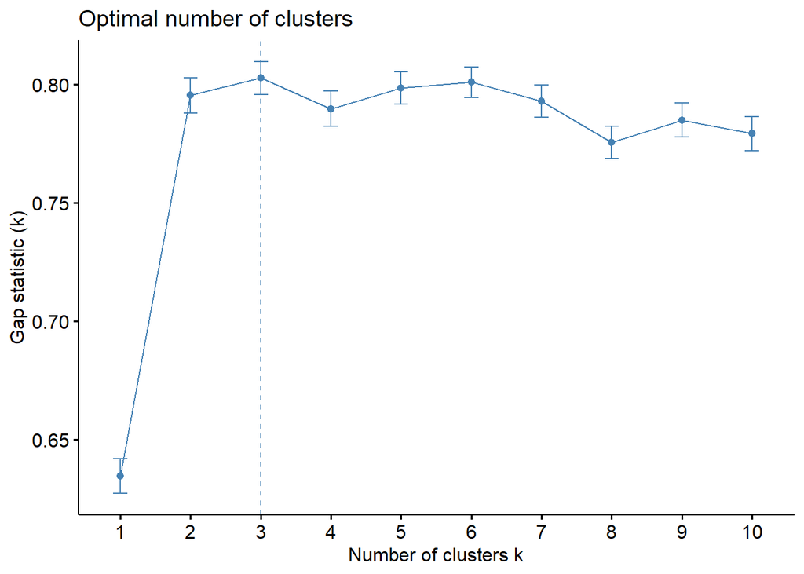

```r
fviz_gap_stat(gs)
```

## Question 10

You need not state an answer to this question, but: does it appear that there are natural clusters in the data that were uncovered using $K$-means, or does it appear that the data were simply split into pieces? (Look at, e.g., `price` versus `carat`; that scatter plot *might* influence your thinking. Note that there not necessarily a right answer here. Interpretation, meet ambiguity.)

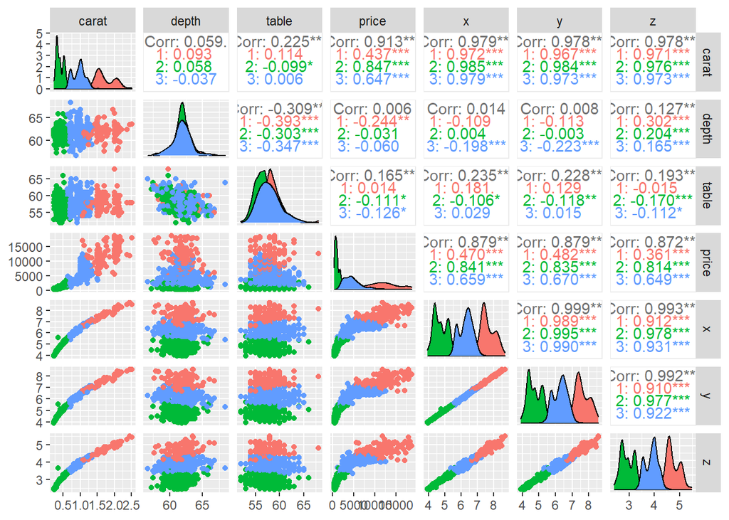

```r
set.seed(202)
# FILL ME IN
km.out = kmeans(scale(df.small),3)
ggpairs(df.small,mapping=aes(color=factor(km.out$cluster)))
```

```r
#there are natural clusters on all pairs of variables except depth vs table
```